**City College of San Francisco**

MATH 108 - Foundations of Data Science

# Lecture 23: Confidence Intervals

Associated Textbook Sections: [13.0, 13.1, 13.2](https://inferentialthinking.com/chapters/13/Estimation.html)

## Set Up the Notebook

```python
from datascience import *
import numpy as np
%matplotlib inline
import matplotlib.pyplot as plots
plots.style.use('fivethirtyeight')
import warnings
warnings.filterwarnings("ignore", category=UserWarning) # hide a UserWarning linked to the datascience library
```

# Table of Contents

## Percentiles

### Computing Percentiles

The Xth percentile is first value on the sorted list that is at least as large as X% of the elements.

The 80th percentile of `[1, 7, 3, 9, 5]` is the 4th ordered (`[1, 3, 5, 7, 9]`) element, 7:

- $(80/100) \cdot 5 = 4$
- `percentile(80, s)` returns `7`

For a percentile that does not exactly correspond to an element, take the next greater element instead

### The percentile Function

- The pth percentile is the smallest value in a set that is at least as large as p% of the elements in the set
- Function in the datascience module: `percentile(p, values)`
  - `p` is between 0 and 100
  - `values` is an array, list, etc.
  - Returns the pth percentile of the array

### Demo: Percentiles

Compute the 55th percentile of the following array.

```python
x = make_array(43, 20, 51, 7, 28, 34)
```

```python
percentile(55, x)
```

```
34
```

Sort the array

```python
np.sort(x)
```

```
array([ 7, 20, 28, 34, 43, 51])
```

Calculate the value of the index corresponding to the percentile. Round up the value.

```python
0.55 * 6
```

```
3.3000000000000003
```

## Estimation

### Inference: Estimation

How do we calculate the value of an unknown parameter?

- If you have a census (that is, the whole population): Just calculate the parameter and you're done
- If you don't have a census:
  - Take a random sample from the population
  - Use a statistic as an estimate of the parameter

### Demo: Sample Median Estimation

Load the [2021 Employee Compensation data from data.sfgov.org](https://data.sfgov.org/City-Management-and-Ethics/Employee-Compensation/88g8-5mnd).

```python
sf = Table.read_table('https://data.sfgov.org/resource/88g8-5mnd.csv?year=2021')
sf.show(3)
```

| organization_group_code | job_family_code | job_code | year_type | year | organization_group | department_code | department | union_code | union | job_family | job | employee_identifier | salaries | overtime | other_salaries | total_salary | retirement | health_and_dental | other_benefits | total_benefits | total_compensation |
| --- | --- | --- | --- | --- | --- | --- | --- | --- | --- | --- | --- | --- | --- | --- | --- | --- | --- | --- | --- | --- | --- |
| 1 | 1000 | 1032 | Calendar | 2021 | Public Protection | ADP | Adult Probation | 21 | Prof & Tech Eng, Local 21 | Information Systems | IS Trainer-Journey | 47369836 | 107167 | 0 | 0 | 107167 | 23017.6 | 15979.3 | 8022.93 | 47019.8 | 154187 |
| 1 | 1000 | 1041 | Calendar | 2021 | Public Protection | ADP | Adult Probation | 21 | Prof & Tech Eng, Local 21 | Information Systems | IS Engineer-Assistant | 47359929 | 132523 | 0 | 0 | 132523 | 27821.3 | 15979.3 | 10320 | 54120.6 | 186644 |
| 1 | 1000 | 1053 | Calendar | 2021 | Public Protection | ADP | Adult Probation | 21 | Prof & Tech Eng, Local 21 | Information Systems | IS Business Analyst-Senior | 45916094 | 12533.2 | 0 | 97.66 | 12630.9 | 2830 | 1536.31 | 988.06 | 5354.37 | 17985.3 |

... (997 rows omitted)

Reduce the table to the `job`, `total_salary`, and `total_compensation` columns.

```python
sf = sf.select('job', 'total_salary', 'total_compensation')
sf
```

| job | total_salary | total_compensation |
| --- | --- | --- |
| IS Trainer-Journey | 107167 | 154187 |
| IS Engineer-Assistant | 132523 | 186644 |
| IS Business Analyst-Senior | 12630.9 | 17985.3 |
| IS Business Analyst-Principal | 170933 | 234841 |
| IS Project Director | 188473 | 256344 |
| IT Operations Support Admin IV | 132808 | 187339 |
| Accountant III | 119910 | 171230 |
| Statistician | 98663.7 | 143715 |
| Senior Administrative Analyst | 124602 | 177403 |
| Senior Administrative Analyst | 89336.1 | 131392 |

... (990 rows omitted)

Who is making the most money?

```python
sf.sort('total_compensation', descending=True).show(5)
```

| job | total_salary | total_compensation |
| --- | --- | --- |
| District Attorney | 309905 | 410754 |
| Assistant Chief Attorney 1 | 268859 | 355220 |
| Chief Atty1 (Civil & Criminal) | 268231 | 354672 |
| Head Atty, Civil & Criminal | 263625 | 350042 |
| Dep Dir IV | 259015 | 347507 |

... (995 rows omitted)

Visually explore the distribution of compensations.

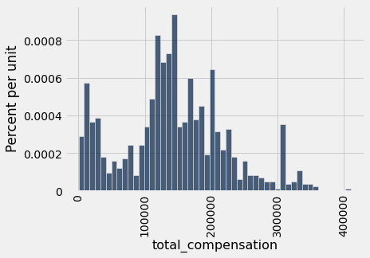

```python
sf.select('total_compensation').hist(bins=50)
```

Filter out the bottom 5% and top 5% of compensations.

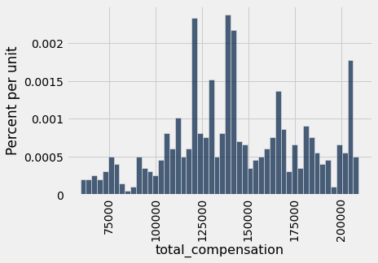

```python
bottom_5 = percentile(5, sf.column('total_compensation'))
top_5 = percentile(95, sf.column('total_compensation'))
sf = sf.where('total_compensation', are.between_or_equal_to(bottom_5, top_5))
sf.select('total_compensation').hist(bins=50)
```

Calculate the median total compensation of this population.

```python
pop_median = np.median(sf.column('total_compensation'))
pop_median
```

```
140198.7
```

Randomly sample 30 employees from the population and calculate the sample median total compensation.

```python
our_sample = sf.sample(30, with_replacement=False)
our_sample
```

| job | total_salary | total_compensation |
| --- | --- | --- |
| Senior Administrative Analyst | 124602 | 177403 |
| Deputy Court Clerk III | 92643.4 | 140777 |
| Court Invstgtor, Superior Crt | 109191 | 161156 |
| Dist Atty Investigator (SFERS) | 148982 | 204501 |
| Deputy Court Clerk II | 55677.2 | 92198.7 |
| Counselor, Family Court Svc | 116500 | 170738 |
| Legal Assistant | 98217.7 | 142993 |
| Victim/Witness Investigator 2 | 96484.3 | 125076 |
| Legal Assistant | 95194 | 139212 |
| Victim/Witness Investigator 3 | 115049 | 165315 |

... (20 rows omitted)

```python
np.median(our_sample.column('total_compensation'))
```

```
141885.4
```

Visually compare the distribution of total compensation values for the population and random sample.

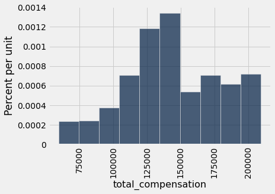

```python
sf.hist('total_compensation', bins=10)
```

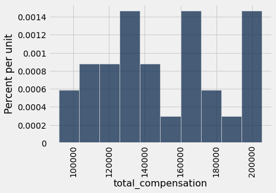

```python
our_sample.hist('total_compensation', bins=10)
```

### Variability of the Estimate

- One sample $\implies$ One estimate
- But the random sample could have come out differently
- And so the estimate could have been different
- **Big question**: How different would it be if we did it again?

### Demo: Variability of the Estimate

Create a function that samples randomly from the `sf` table and returns the sample median for `total_compensation`.

```python
def generate_sample_median(sample_size):
    our_sample = sf.sample(sample_size, with_replacement=False)
    return np.median(our_sample.column('total_compensation'))
```

```python
sample_median = generate_sample_median(30)
sample_median
```

```
134530.395
```

Compute the error if the sample median is used to estimate the population median for total compensation. Re-run the above function to see how the error varies.

```python
error = sample_median - pop_median
error
```

```
-5668.305000000022
```

### Quantifying Uncertainty

- The estimate is usually not exactly right: `Estimate = Parameter + Error`
- How accurate is the estimate, usually?
- How big is a typical error?
- When we have a census, we can do this by simulation

### Demo: Quantifying Uncertainty

```python
sample_medians = make_array()

for __ in np.arange(1000):
    sample_medians = np.append(sample_medians, generate_sample_median(30))
```

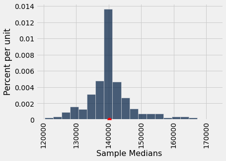

```python
Table().with_column(
    'Sample Medians', sample_medians
).hist(bins=20)

plots.scatter(pop_median, 0, color="red", s=60, zorder=3);
```

Visualize the distribution of errors found from using the sample medians to estimate the population median.

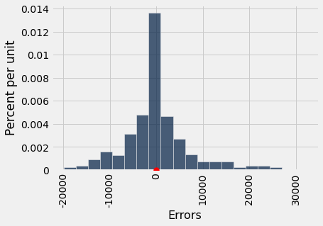

```python
Table().with_column(
    'Errors', sample_medians - pop_median
).hist(bins=20)

plots.scatter(0, 0, color="red", s=60, zorder=3);
```

### Where to Get Another Sample?

- We want to understand errors of our estimate
- Given the population, we could simulate... but we only have the sample!
- To get many values of the estimate, we needed many random samples
- We can't go back and sample again from the population:
  - No time, no money
  - Stuck?

## The Bootstrap

### The Bootstrap

- A technique for simulating repeated random sampling
- All that we have is the original sample... which is large and random
- Therefore, it probably resembles the population
- So we sample at random from the original sample!

### Why the Bootstrap Works

All of the resamples look pretty **similar**, most likely.

[figure not shown]

### Why We Need the Bootstrap

[figure not shown]

### Real World vs. Bootstrap World

- Real world:
  - True probability distribution (population)
    - Random sample 1 $\leadsto$ Estimate 1
    - Random sample 2 $\leadsto$ Estimate 2
    - ...
    - Random sample 10000 $\leadsto$ Estimate 10000
- Bootstrap world:
  - Empirical distribution of original sample ("population")
    - Bootstrap sample 1 $\leadsto$ Estimate 1
    - Bootstrap sample 2 $\leadsto$ Estimate 2
    - ...
    - Bootstrap sample 10000 $\leadsto$ Estimate 10000

The Hope: these two scenarios are analogous

### The Bootstrap Principle

- The bootstrap principle: Bootstrap-world sampling $\approx$ Real-world sampling
- Not always true! ... but reasonable if sample is large enough
- We hope that the following are similar to what they are in the real world
  - Variability of bootstrap estimate
  - Distribution of bootstrap errors

### Key to Resampling

- From the original sample,
  - draw at random
  - with replacement
  - as many values as the original sample contained
- The size of the new sample has to be the same as the original one, so that the two estimates are comparable

### Demo: Bootstrap

Take a bootstrap (re)sample (**WITH replacement**) of size 30 from the last sf sample.

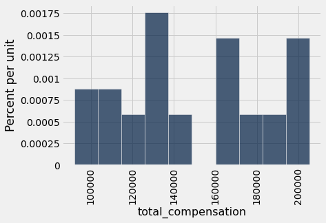

```python
boot_sample = our_sample.sample(30, with_replacement=True) # our_sample.sample() does the same thing.
boot_sample.hist('total_compensation', bins=10)
```

Explore the distribution of 1000 bootstrap resamples from the one sample in relation to the sample median and population median.

```python
def one_bootstrap_median():
    return np.median(our_sample.sample().column('total_compensation'))
```

```python
bootstrap_medians = make_array()

for __ in np.arange(1000):
    bootstrap_medians = np.append(bootstrap_medians, one_bootstrap_median())
```

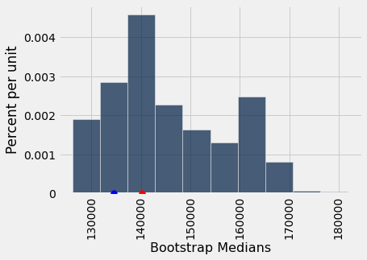

```python
Table().with_column(
    'Bootstrap Medians',
    bootstrap_medians
).hist(bins=10)

plots.scatter(pop_median, 0, color='red', s=60, zorder=3)
plots.scatter(sample_median, 0, color='blue', s=60, zorder=3);
```

## Confidence Intervals

### 95% Confidence Interval

- Interval of estimates of a parameter
- Based on random sampling
- 95% is called the confidence level
  - Could be any percent between 0 and 100
  - Higher level means wider intervals
- The confidence is in the process that gives the interval: It generates a "good" interval about 95% of the time.

### Demo: Confidence Intervals

Make an interval based on the middle 95% of bootstrap samples.

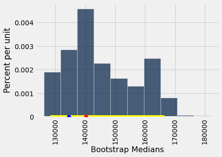

```python
left = percentile(2.5, bootstrap_medians)
right = percentile(97.5, bootstrap_medians)

Table().with_column(
    'Bootstrap Medians',
    bootstrap_medians
).hist(bins=10)

plots.plot([left, right], [0,0], color="yellow", lw=6, zorder=3)
plots.scatter(pop_median, 0, color='red', s=60, zorder=4)
plots.scatter(sample_median, 0, color='blue', s=60, zorder=4);
```

### Visualizing Confidence

- Each yellow line in the visual represents a confidence interval from a fresh sample from the population.
- The red line marks the parameter being estimated by the intervals.
- Approximately 95% of the yellow lines intersect the red line.

[figure not shown]

A similar tool to help visualize the meaning of a confidence interval: [Interpreting Confidence Intervals](https://rpsychologist.com/d3/ci/)